# Anomaly Detection in Network Traffic with K-means clustering

### 2.2.4. Choosing K

How many clusters are appropriate for a dataset? In particular, for our own dataset, it's clear that there are 23 distinct behavior patterns in the data, so it seems that k could be at least 23, or likely, even more. In other cases, we even don't have any information about the number of patterns at all (remember, generally your data is not labelled!). Our task now is finding a good value of $k$. For doing that, we have to build and evaluate models with different values of $k$. A clustering could be considered good if each data point were near to its closest centroid. One of the ways to evaluate a model is calculating the Mean of Squared Errors of all data points.

[figure not shown]

#### Question 6

Complete the function below to calculate the MSE of each model that is corresponding to each value of $k$. Plot the results. From the obtained result, what is the best value for $k$? Why?

```python
# k: the number of clusters
def clusteringScore(data, k):
    clusters = KMeans.train(data, k, maxIterations=10, initializationMode="random")
    # calculate mean square error
    MSE1 = data.map(lambda x: (error(clusters,x)**2)).reduce(add)
    MSE = MSE1/n
    return MSE
```

```
[1302338512760.5144, 1302338531793.1394, 1302338512501.2478, 1302338529363.7903, 1302338503802.5442, 1302338457432.5942]
```

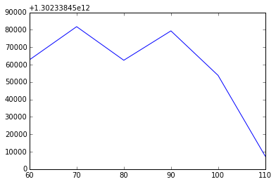

```python
list = [60,70,80,90,100,110]
#list = [2, 5]
scores = []
for k in list:
    scores.append(clusteringScore(data, k))

print(scores)

# plot results
plt.plot(list, scores)
plt.show()
```

The best number of cluster is 110 in the value we tested. It is because the error we gauged depends on the distance between a point and his closest center so with more centers the point are closer to a center than if they were less centers. However it is not necessary the case as we can see on the graph, the error is bigger for 90 than for 80. We believe it is because we chose the first centroids randomly and the maximum of iterations is 10 so maybe the algorithm is not finished and we obtain a worse result than with a smaller number of clusters.

### 2.2.5 Normalizing features

K-means clustering treats equally all dimensions/directions of the space and therefore tends to produce more or less spherical (rather than elongated) clusters. In this situation, leaving variances uneven is equivalent to putting more weight on variables with smaller variance, so clusters will tend to be separated along variables with greater variance.

In our notebook, since Euclidean distance is used, the clusters will be influenced strongly by the magnitudes of the variables, especially by outliers. Normalizing will remove this bias.

Each feature can be normalized by converting it to a standard score. This means subtracting the mean of the feature’s values from each value, and dividing by the standard deviation

$normalize_i=\frac{feature_i - \mu_i}{\sigma_i}$

Where,

- $normalize_i$ is the normalized value of feature $i$
- $\mu_i$ is the mean of feature $i$
- $\sigma_i$ is the standard deviation of feature $i$

[figure not shown]

#### Question 7

Complete the code below to normalize the data. Print the first 5 lines of the new data.

HINT

If $\sigma_i = 0$ then $normalize_i=feature_i - \mu_i$

```python
import math as m

def normalizeData(data):
    # number of connections
    n = data.count()
    # calculate the sum of each feature
    sums = data.reduce(lambda x,y : [x[i]+y[i] for i in range(len(x))])
    print("sums: ", sums)

    # calculate means
    means = [sums[i]/n for i in range(len(sums))]

    # calculate the sum square of each feature
    sumSquares = data.map(lambda x: [(x[i]-means[i])**2 for i in range(len(x))]).reduce(lambda x,y : [x[i]+y[i] for i in range(len(x))])
    print("sumSquares : ", sumSquares)

    # calculate standard deviation of each feature
    stdevs = [m.sqrt(sumSquares[i]/n) for i in range(len(sums))]
    print("stdevs: ", stdevs)

    def normalize(point):
        L = []
        for i in range(len(sums)):
            if stdevs[i] == 0:
                L.append(point[i]-means[i])
            else:
                L.append((point[i]-means[i])/stdevs[i])
        return L


    return data.map(normalize)

normalizedData = normalizeData(data).cache()
print("5 normalized Data: ", normalizedData.take(5))
```

[output not shown]

```python
normalizedData_sample = normalizedData.sample(withReplacement=False,fraction=0.001)
```

[figure not shown]

#### Question 8

Using the new data, build different models with different values of $k \in [60,70,80,90,100,110]$. Evaluate the results by plotting them and choose the best value of $k$.

```
[4652.440488005241, 7487.067466786814, 16406.660834418206, 11090.315661035136, 26327.44264928913, 30843.38716642125]
```

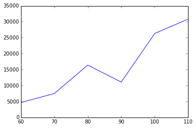

```python
list = [60, 70, 80, 90, 100, 110]
scores = []
for k in list:
    scores.append(clusteringScore(normalizedData, k))

print(scores)

# plot results
plt.plot(list, scores)
plt.show()
```

results: [4652.440488005241, 7487.067466786814, 16406.660834418206, 11090.315661035136, 26327.44264928913, 30843.38716642125] in case we lost them

After normalisation the results change completely. Instead of decreasing with k, the error increases with k.  
It is good for us because it means less computation. Thus we will choose 60 for k.

[figure not shown]

#### Question 9

Plot the clustering result to see the difference between before and after normalizing features. Discuss about the difference and explain why and if normalization was useful.

```
Repartition in percentage :
 class 0:  40.2705886844
 class 1:  59.7294113156
```

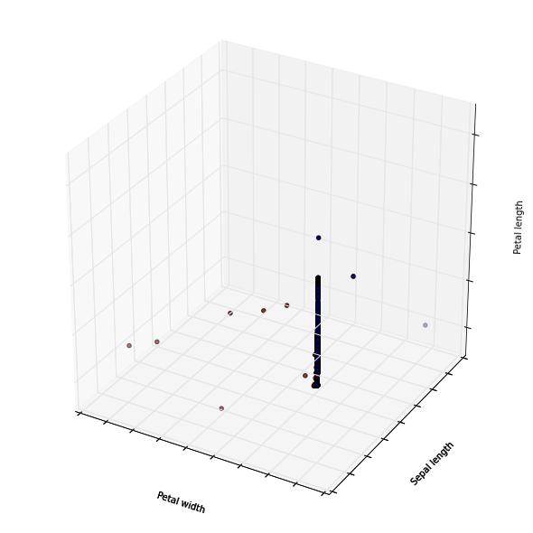

```
Repartition in percentage :
 class 0:  59.5139749851
 class 1:  40.4860250149
```

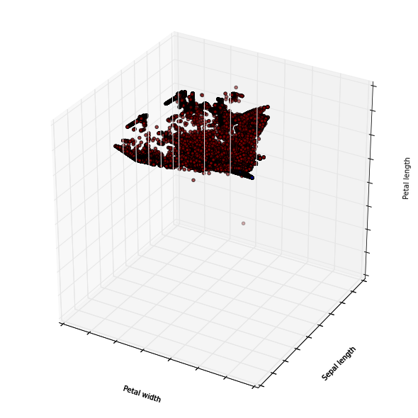

```python
##We work only with 2 clusters because if not it takes too much time to do it

clusters = KMeans.train(data, 2, maxIterations=10, initializationMode="random")
#We predict the class using our clusters
labels2 = clusters.predict(data).collect()

clustersNormalized = KMeans.train(normalizedData, 2, maxIterations=10, initializationMode="random")
#We predict the class using our clusters
labels2Normalized = clustersNormalized.predict(normalizedData).collect()

plotPredict(labels2,data,2)
plotPredict(labels2Normalized,normalizedData,2)
```

## 2.3. Clustering using categorical features

### 2.3.1 Loading data

In the previous section, we ignored the categorical features of our data: this is not a good idea, since these categorical features can be important in providing useful information for clustering. The problem is that K-means (or at least, the one we have developed and the one we use from MLLib) only work with data points in a metric space. Informally, this means that operations such as addition, subtraction and computing the mean of data points are trivial and well defined. For a more formal definition of what a metric space is, follow this [link](https://en.wikipedia.org/wiki/Metric_space#Definition).

What we will do next is to transform each categorical feature into one or more numerical features. This approach is very widespread: imagine for example you wanted to use K-means to cluster text data. Then, the idea is to transform text data in $d$-dimensional vectors, and a nice way to do it is to use word2vec. If you're interested, follow this link to a nice [blog post](http://bigdatasciencebootcamp.com/posts/Part_3/clustering_news.html) on the problem.

  ```
  [
  [1,0,0,0],
  [0,1,0,0],
  [0,0,1,0],
  [0,0,0,1],
  ]
  ```

We call the second approach "one-hot encoding". By using this approach, we keep the same role for all values of categorical features.

[figure not shown]

#### Question 10

Calculate the number of distinct categorical features value (at index `1,2,3`). Then construct a new input data using one-hot encoding for these categorical features (don't throw away numerical features!).

```python
# We need to compute before the vectors containing all of the distincts values for cols[1], cols[2], cols[3]
def getDistictVect(i):
    def getIt(line):
        cols = line.split(',')
        vector = cols[i]
        return vector
    return raw_data.map(getIt).distinct().collect()
vectDistinct1 = getDistictVect(1)
vectDistinct2 = getDistictVect(2)
vectDistinct3 = getDistictVect(3)
```

```python
# We must modify our function because we have columns which are arrays and not float so we cannot normalize them
# as we did for float. But given the fact that their values are only 1 or 0 in the array, we can consider that
# there are already normalized and operate the function only on the other columns. That is what this new function does.

def normalizeData(data):
    def howToReduceSum(a,b):
        if type(a)==float:
            return a+b
        else :
            return 0

    def howToSquare(a,i):
        if type(a)==float:
            return (a-means[i])**2
        else :
            return(0)

    # number of connections
    n = data.count()


    # calculate the sum of each feature
    sums = data.reduce(lambda x,y : [howToReduceSum(x[i],y[i]) for i in range(len(x))])
    print("sums : ",sums,'\n')

    # calculate means
    means = [sums[0]/n]+[0]+[0]+[0]+[sums[i]/n for i in range(4,len(sums))]

    print(means)
    # calculate the sum square of each feature
    sumSquares = data.map(lambda x: [howToSquare(x[i],i) for i in range(len(x))]).reduce(lambda x,y : [x[i]+y[i] for i in range(len(x))])
    print("sumSquares : ",sumSquares)

    # calculate standard deviation of each feature
    stdevs = [m.sqrt(sumSquares[i]/n) for i in range(len(sums))]

    def normalize(point):
        #return [(point[i]-means[i])/stdevs[i] for i in range(len(sums))]
        L = []
        for i in range(len(sums)):
            if i in [1,2,3]:
                L.append(point[i])
            else:
                if stdevs[i] == 0:
                    L.append(point[i]-means[i])
                else:
                    L.append((point[i]-means[i])/stdevs[i])
        return L
    return data.map(normalize)
normalizedData = normalizeData(data)    .cache()
```

```python
def parseLineWithHotEncoding(line):
    def generateVect(i,n):
        return [1 if j==i else 0 for j in range(n)]
    cols = line.split(',')
    # label is the last column
    label = cols[-1]

    vector = cols[0:-1]

    # the binary features that are encoded from the first categorical features

    featureOfCol1 = generateVect(vectDistinct1.index(vector[1]),len(vectDistinct1))
    # the binary features that are encoded from the second categorical feature
    featureOfCol2 = generateVect(vectDistinct2.index(vector[2]),len(vectDistinct2))
    # the binary features that are encoded from the third categorical feature
    featureOfCol3 = generateVect(vectDistinct3.index(vector[3]),len(vectDistinct3))

    # construct the new vector
    vector = ([float(vector[0])] + [featureOfCol1] +[featureOfCol2] +
        [featureOfCol3] + [float(vector[i]) for i in range(4,len(vector))])

    return (label, vector)

labelsAndData = raw_data.map(parseLineWithHotEncoding).sample(withReplacement=False,fraction=0.01)

# we only need the data, not the label
data = labelsAndData.values().cache()


normalizedData = normalizeData(data).cache()
```

### 2.3.2. Building models

[figure not shown]

#### Question 11

Using the new data, cluster the connections with different values of $k \in [80,90,100,110,120,130,140,150,160]$. Evaluate the results and choose the best value of $k$ as previous questions.

```python
list = [80, 110, 160]

scores = []
for k in list:
    scores.append(clusteringScore(normalizedData, k))

print(scores)

# plot results
plt.plot(list, scores)
plt.show()
```

[output not shown]

We didn't have time to compute it again because we noticed that we made a mistake before and we had to recompute it all today which takes a lot of time.

## 2.4. Anomaly detection

When we have a new connection data (e.g., one that we never saw before), we simply find the closest cluster for it, and use this information as a proxy to indicate whether the data point is anomalous or not. A simple approach to decide when there is an anomaly or not, amounts to measuring the new data point’s distance to its nearest centroid. If this distance exceeds some thresholds, it is anomalous.

[figure not shown]

#### Question 12

Build your model with the best value of $k$ in your opinion. Then, detect the anomalous connections in our data. Plot and discuss your result.

HINT

The threshold has strong impact on the result. Be careful when choosing it! A simple way to choose the threshold's value is picking up a distance of a data point from among known data. For example, the 100th-farthest data point distance can be an option.

It seems strange for us to do the 100th-farthest because if we have 100 clusters it means we couldn't have more than 10 000 correct points. We believe we should pick a higher number.

[figure not shown]

#### Question 13

Try other methods to find the best value for $k$ such as `silhouette`, `entropy`... In particular, with this data, you can take advantage of predefined labels to calculate the quality of model using entropy... However, we suggest you to try with `silhouette`. It's more general and can work with any dataset (with and without predefined labels).

Here are some additional information about the metrics we suggest to use:

- Silhouette
- [Hack approach to Silhouette](http://scikit-learn.org/stable/auto_examples/cluster/plot_kmeans_silhouette_analysis.html)
- [Entropy](http://scikit-learn.org/stable/modules/clustering.html) [Lookup for entropy]

Note

you are free to play with any relevant evaluation metric you think appropriate for your work!

```python
from sklearn import metrics

#k number of clusters
def silhouette(data, k):
    clusters = KMeans.train(data, k, maxIterations=10, initializationMode="random")
    #calculate the silhouette error
    silhouette_avg = metrics.silhouette_score(data, clusters.clusterCenters)
    return silhouette_avg

silhouette_avg = silhouette(normalizedData_sample, 2)
```

[output not shown]

We didn't have time to correct our mistake because we had to re-run everything.

[figure not shown]

#### Question 14

Implement K-means on Spark so that It can work with large datasets in parallel. Test your algorithm with our dataset in this notebook. Compare our algorithm with the algorithm from MLLIB.

Let's clarify the meaning of this question: what we want is for students to design the K-means algorithm for the parallel programming model exposed by Spark. You are strongly invited to use the Python API (pyspark). So, at the end of the day, you will operate on RDDs, and implement a `map/reduce` algorithm that performs the two phases of the standard K-means algorithm, i.e. the assignment step and the update step.